# hw6_EvolutionaryRates

Daisy Fry-Brumit

2022-11-29

### Question 1: Out of the 70 loci that we started with, did all of them show clock-like evolution? If not, then how many loci did “pass” the relative rates test? (2 pts)

Not all loci passed our test, but 17 did.

### Question 2: In the original study where I pulled these loci, they used the HKY + I model for all of their partitions. Based on the model test results…

```
##              clock.like
## my.sub.models 1 4 11 14 21 23 24 26 28 30 31 34 36 45 47 54 63
##      F81      0 0  1  0  0  0  0  0  0  0  0  0  0  0  0  0  0
##      HKY+G(4) 0 0  0  0  0  1  0  0  0  0  0  0  0  0  0  1  0
##      HKY+I    0 0  0  1  0  0  0  0  0  0  0  0  1  1  0  0  0
##      K80      0 1  0  0  0  0  0  1  0  0  0  0  0  0  0  0  0
##      K80+G(4) 0 0  0  0  0  0  0  0  0  0  0  0  0  0  1  0  0
##      K80+I    0 0  0  0  1  0  0  0  1  0  0  1  0  0  0  0  1
##      TIM3     0 0  0  0  0  0  1  0  0  0  0  0  0  0  0  0  0
##      TPM1u    0 0  0  0  0  0  0  0  0  0  1  0  0  0  0  0  0
##      TPM3     1 0  0  0  0  0  0  0  0  0  0  0  0  0  0  0  0
##      TrNe+I   0 0  0  0  0  0  0  0  0  1  0  0  0  0  0  0  0
```

#### Is the HKY + I model the best fit for the majority of the loci?

No.

#### How many loci do fit this model of substitution?

3 fit this HKY + I

#### How many total different models are there for these loci? (hint: you might find the table() function in R to be useful for this.) (3 pts)

There are 10 different models that fit within this collection of loci

### Question 3: Show the plot of your molecular clock tree with divergence times. (5 pts)

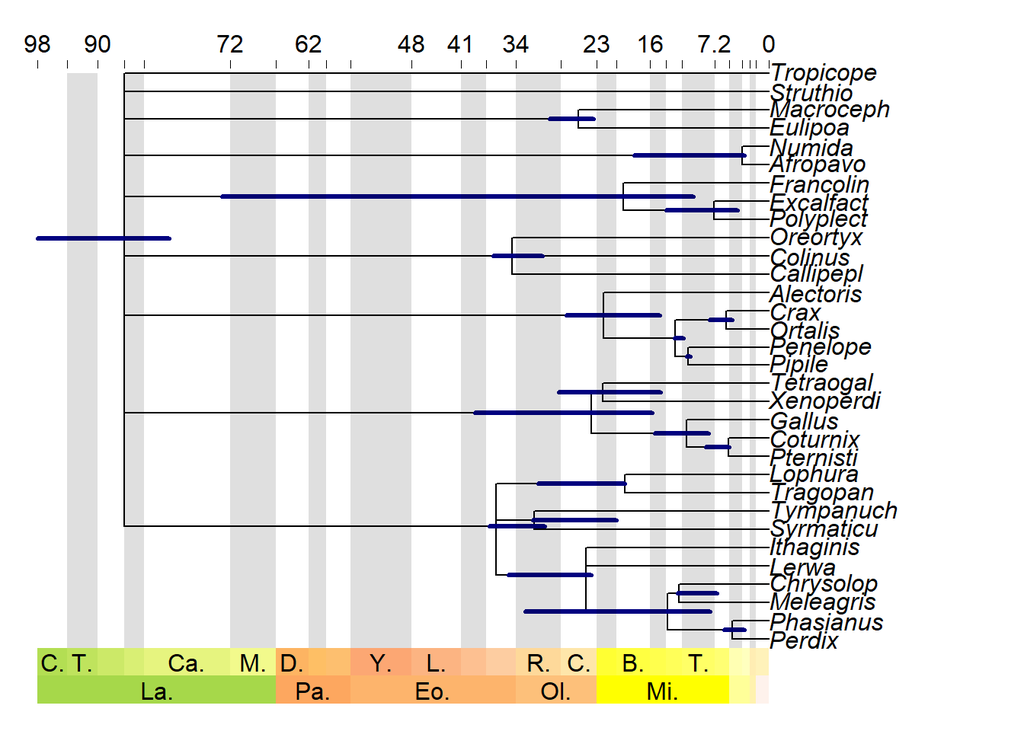

### Question 4: According to your results, what is the closest relative of the Wild Turkey (at least among these species)? Approximately when did the turkey diverge from this relative? (2 pts)

The closest relative seems to be the Golden pheasant (“Chrysolop” on the tree) and they diverged roughly 14 mya.

### Question 5: Based on the test results, do the diversification rates appear constant over time, or is there evidence for a shift in rates? (1 pt)

The null model here is exponential, and the p values are significant, so I would anticipate a shift in rates over time

### Question 6: According to this analysis, how many rate shifts were there in the history of these species? (1 pt)

There appear to have been 2 shifts

### Question 7: Show your MEDUSA plot with rate shifts. (5 pts)

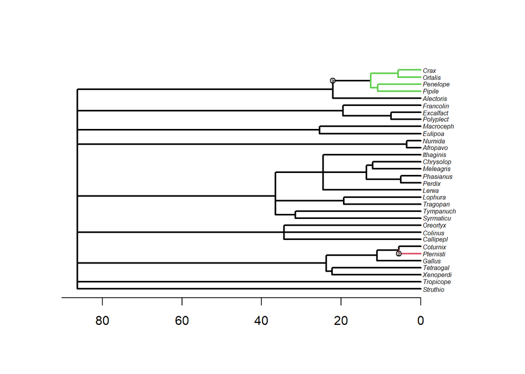

### Question 8: Which clade appears to be evolving the fastest? (1 pt)

I think the Coturnix/Pternisti clade shown in red looks like it’s evolving the fastest

### Question 9: Based on these results, do you think the hypothesis about sexual dimorphism driving faster evolution is supported? Why or why not? (5 pts)

I think there’s *some* evidence of this. While there are only two detectable shifts based on this analysis, the branch lengths on our overall tree trend shorter as we advance through history, and some of the clades (the Chrysolop/Lerwa clade, for example) show some pretty recent divergence times. I don’t know how compelling this argument is compared to other, less sexually dimorphic birds, but this looks more to me like the figures we’ve seen in class with increased rates of evolution, if only slightly.